# Example analysis eukaryotic metatranscriptome

Sarah Hu

1/19/2022

# Background

Data derived from [Hu *et al.* 2018](https://doi.org/10.1111/1462-2920.14259), complete github can be found [here](https://github.com/shu251/SPOT_metatranscriptome).

## Data analysis

Question for ordination analysis: **How similar are the dominant microeukaryote taxonomic groups at each depth?**

In order to appropriately assess across different taxonomic groups and sample depths, we subset the read counts so there were not zeroes. Meaning, we retained read counts of shared KEGG IDs across the 5 taxonomic groups. This subset of shared counts was created first (see 'counts-bytaxa-sharedKeggIDs.csv').

Below R script will walk through importing this data, performing normalization (considering replicates), and downstream ordination.

# Set up working R environment & import data

Load libraries needed.

```r
# if (!requireNamespace("BiocManager", quietly = TRUE))
#     install.packages("BiocManager")
#
# BiocManager::install("edgeR")
# install.packages("tidyverse")
# install.packages("vegan)

library(tidyverse)
library(edgeR)
library(vegan)
```

Import .csv file

```r
countfile <- read.csv("counts-bytaxa-sharedKeggIDs.csv")

# names(countfile) # column names
```

Normalize with edgeR. Using the `DGEList()` command to assign which columns are count data, KEGG/annotation information, and replicates for the 3 sample depths.

```r
dge.metaT.cca <- DGEList(counts = countfile[,3:15],
                         genes = countfile[1:2],
                         group=c(rep("Surface",6),
                                 rep("Deep_150m",3),
                                 rep("Deep_890m",4)))
# List library size, and samples as grouped replicates.
dge.metaT.cca$samples
```

```
##              group lib.size norm.factors
## Sample7    Surface  1578111            1
## Sample8    Surface   841926            1
## Sample9    Surface  2219463            1
## Sample10   Surface  2707843            1
## Sample11   Surface  2225508            1
## Sample12   Surface  1928552            1
## Sample25 Deep_150m  2312033            1
## Sample26 Deep_150m  1484394            1
## Sample27 Deep_150m  2800940            1
## Sample28 Deep_890m   726718            1
## Sample29 Deep_890m  2904457            1
## Sample30 Deep_890m  2200135            1
## Sample31 Deep_890m  2524094            1
```

Note the last column from the previous output lists the 'norm.factors'. In this next step we will do a normalization called TMM or trimmed mean

```r
#normalize library using trimmed mean of M-values
data <- calcNormFactors(dge.metaT.cca, method = "TMM")
# ?calcNormFactors() #explore other options
```

Change to normalized counts per million (not logged)

```r
cpm_data <- cpm(data, normalized.lib.sizes=TRUE, log=FALSE)
cpm_data <- as.data.frame(cpm_data)

# Compile with annotation information ($genes)
cca_cpm <- data.frame(data$genes, cpm_data)
```

```r
#Calculate relative abundance the mean CPM by taxonomic group.
norm.m.data_CPM <- cca_cpm %>%
  pivot_longer(starts_with("Sample")) %>%
  group_by(Level2, name) %>%
  mutate(count_norm = value/sum(value)) %>%
  select(-value) %>%
  pivot_wider(names_from = K0_number, values_from = count_norm, values_fill = 0) %>%
  unite(tmp, Level2, name, sep = "_", remove = FALSE) %>%
  select(tmp, Level2, variable = name, everything()) %>%
  column_to_rownames(var = "tmp") %>%
  data.frame
# head(norm.m.data_CPM)
```

Add in values for symbols and colors.

```r
#format a key:
key_forPCA<-function(df){
  df$shape<-22 #surface
  deep150<-c("Sample25", "Sample26", "Sample27")
  df$shape[df$variable %in% deep150]=21
  deep890<-c("Sample28", "Sample29", "Sample30", "Sample31")
  df$shape[df$variable %in% deep890]=24
  #select taxa:
  df$taxcolor[df$Level2=="Dinoflagellate"]="#c2a5cf"
  df$taxcolor[df$Level2=="Ciliate"]="#d53e4f"
  df$taxcolor[df$Level2=="Diatom"]="#e6f598"
  df$taxcolor[df$Level2=="Chlorophyte"]="#5aae61"
  df$taxcolor[df$Level2=="Haptophyte"]="#f46d43"
  return(df)
}
cpm_PCA.w.key<-key_forPCA(norm.m.data_CPM)
```

```r
# Isolate key and count data only
CCA_data <- cpm_PCA.w.key %>% select(-Level2, -variable, -shape, -taxcolor) #only numerica in CCA input information

key <- cpm_PCA.w.key %>% select(Level2, variable, shape, taxcolor)
```

### CCA input and isolation of eigenvalues:

Input data is all numeric with rownames equal to the categories I want to show in the legend of my ordination. In this case, it is sample (depth) and taxa. Values are normalized counts (Relative abundance), and columns are each of the KEGG identities of the reads.

```r
# head(CCA_data) # View data frame structure this way
set.seed(111) #for reproducibility
ca <- cca(CCA_data, scaling=TRUE)
```

Using base R to plot outputs.

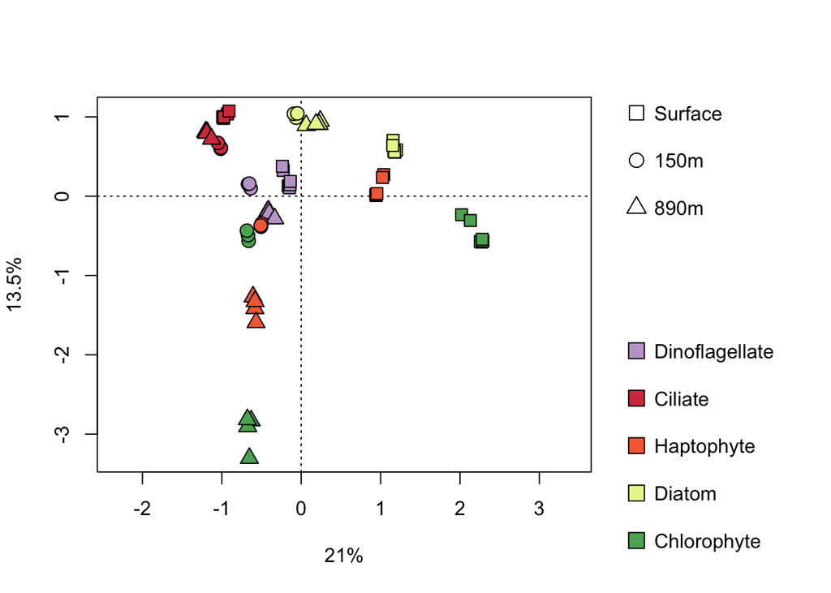

```r
#CCA ploting set up:
par(xpd = FALSE, oma = c(0,0,0,8))
# Isolate variances for axes
eig<-eigenvals(ca); x<-signif((eig[1]*100),3); y<-signif((eig[2]*100),3) #extract variances for CCA1 and CCA2 axes

plot(ca,type=c("points"),display=c("wa", "sites"),main="",xlab=bquote(.(x)*"%"), ylab=(bquote(.(y)*"%")))
points(ca,pch=key$shape,col="black",bg=key$taxcolor,cex=1.5)
par(xpd=NA)
legend(4,1.5,c("Surface", "150m", "890m"),pch=c(0,1,2),col=c("black"),cex=1,pt.cex=1.6,bty="n",y.intersp=2)
legend(4,-1.5,c("Dinoflagellate","Ciliate","Haptophyte","Diatom","Chlorophyte"),pch=22,pt.bg=c("#c2a5cf","#d53e4f", "#f46d43", "#e6f598", "#5aae61"),col=c("black","black","black","black","black"),y.intersp=2,bty="n",pt.cex=2,cex=1)
```